# GDSC Data Download and Exploration

## 5.1 Compounds

This should be roughly the same data as in the “screened_compunds_rel_8.2.csv” file from the current release FTP.

## 5.2 Cell Lines

Here is where we get to have a lot of fun. Notice the order of the six (6) columns in the tsv export: “COSMIC_ID”, “Name” “COSMIC_ID”, “Tissue”, “Tissue sub-type”, “Count”. Compare these to the columns in the preview. Also, the actual number of fields is 10. The “Cell Passports Model” is now the first column, but is called “COSMIC_ID.” The Cell Passports Model id is repeated as the fourth column after COSMIC_id.

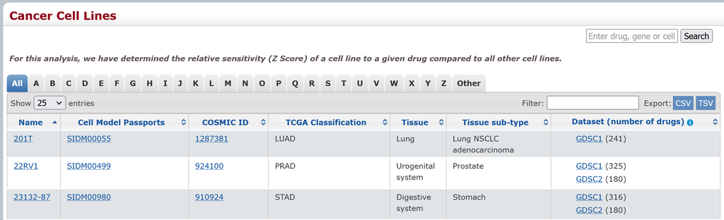

The cell lines data export has roughly the same data as in the “Cell_Lines_Details.xlsx” file from the current release FTP.

## 5.3 Genetic Features Results

Again, there seems to be two places to download the cell features. One is the *Features* page. The other is through the *Downloads* page form. The files from the *Features* page appear to be a kind of metadata about the features that is not specific to any cell line. The files form the *Downloads* page seem to be the features discovered for each cell line through the machine learning. Thus, we would expect the number of rows in these files to be approximately the number of cell lines times the number of features.

For PANCANCER, the features metadata file (from the *Features* page, *genetic_features_PANCANCER.tsv*) lists 693 unique features.

### 5.3.1 Pancancer

The cell lines metadata file (from the *Cell Lines* page) lists 988 cell lines.

The product is 693 × 988 = 684,684 combineations.

The PANCANCER data file (cell lines and genetic features) has 583,305 records, so somewhat less. It’s reasonable that some cell lines simply did not have all genetic features.

So, hopefully my assumptions about these files are correct.

It was hard to figure out how to capture the URL to GET the features for each cancer type. I was able to determine it by inspecting the download button which has a property called `data-base-url` with the value `/downloads/download/genetic_feature`. Also, after making choices from the dropdowns (e.g. Screening Set, Select Tissue Type, Select Mutation Type), the page URL would look like `https://www.cancerrxgene.org/downloads/genetic_features?tissue=ALL&mutation=both&screening_set=GDSC1`. The trick was to combine the two ideas and remove the “s” from “genetic_features.” For instnce:

`https://www.cancerrxgene.org/downloads/download/genetic_feature?tissue=ALL&mutation=both&screening_set=GDSC1`

These files are a complete trainwreck because they are CSV files with an array column (Genes in Segment) that is comma-delimited. Luckily, this column is the last of the 10 columns. So by replacing the commas with tabs (using `awk`), I convert the file to tab-delimited with a comma-delimited array column as the last column.

### 5.3.2 All TCGA

### 5.3.3 Combine Individual Tissue Types

Because the total records for individual tissues is much less than for PANCANCER, IMO it makes sense to combine these into a single file and add a column for *tcga_cancer_type*. This is pretty easy using awk. I’ll do it for both sets of features files—downloads page and Features page.

### 5.3.4 Delete Intermediate Files

## 5.4 Genetic Features Metadata

### 5.4.1 Pancancer

### 5.4.2 Download All TCGA Cancer Types

### 5.4.3 Combine TCGA Cancer Types

Eliminate “Count” column—last column #5.

### 5.4.4 Delete Intermediate Files

# 6 Conclusion

We have shown how to download all of the data files from the GDSC website. Some tables are located in multiple places (thee in the case of the drug data), but the format and number of records is not consistent. Some tables download in formats that cannot be read, and others with incomplete or incorrect headers. Also some tables with the *same* data may not have all the same columns.

Therefore, we must have a clear strategy when downloading tables from GDSC for how to combine, normalize, and harmonize the data.

Save excel sheets to tsv files.

Systematize schema generation. Put in tsv file. colname, description, type, mode

Where to get more descriptions?